# Description et prévision de données temporelles

NDIAYE & SYLLA & BODIAN & FALL

2024-11-09

### Nettoyage des données

Pour le nettoyage des données, nous avons suivi les étapes suivantes :

1. **Normalisation des heures**
   - Nous avons uniformisé le format des heures en remplaçant les séparateurs “h” par “:” afin d’obtenir un format cohérent de type `hh:mm:ss`.
   - Ces valeurs ont ensuite été converties en un format numérique exprimé en heures.
2. **Suppression des lignes sans enregistrement de poids**
   - Étant donné que le poids est la variable centrale de notre analyse, nous avons décidé de supprimer les lignes où aucune valeur de poids n’était enregistrée.
   - Ce choix nous semblait pertinent, car ces données manquantes auraient pu fausser les résultats.
3. **Réduction du jeu de données**
   - Après le nettoyage, le nombre de lignes a été réduit de 115 à 81.
4. **Importation des données nettoyées dans R**
   - Une fois les données nettoyées, nous les avons enregistrées dans un fichier que nous avons ensuite importé dans R pour les étapes suivantes de l’analyse.

Nous inclurons ce fichier nettoyé parmi les documents que nous soumettrons lors du dépôt, afin que vous puissiez exécuter notre code dans les meilleures conditions possibles.

# Chargement et pretraitement des données depuis le fichier Excel nettoyer

```r
data1 <- read_excel("C:\\Users\\nsoul\\Downloads\\kana.xlsx", sheet = 1)
data2 <- read_excel("C:\\Users\\nsoul\\Downloads\\kana.xlsx", sheet = 2)


# Affichage rapide des données data1 pour la phase 1 et data2 pour la phase 2
head(data1)
```

```
## # A tibble: 6 × 4
##   Jour                Heure               Poids Date
##   <dttm>              <dttm>              <dbl> <dttm>
## 1 2020-05-17 00:00:00 1899-12-31 09:39:00  99.1 2020-05-17 09:39:00
## 2 2020-05-17 00:00:00 1899-12-31 10:02:00  99.7 2020-05-17 10:02:00
## 3 2020-05-17 00:00:00 1899-12-31 10:25:00  99   2020-05-17 10:25:00
## 4 2020-05-17 00:00:00 1899-12-31 10:56:00  99.2 2020-05-17 10:56:00
## 5 2020-05-17 00:00:00 1899-12-31 11:41:00  99.3 2020-05-17 11:41:00
## 6 2020-05-17 00:00:00 1899-12-31 12:30:00  98.8 2020-05-17 12:30:00
```

```r
head(data2)
```

```
## # A tibble: 6 × 5
##   Jour       Heure               Poids `Graisse_%` Date
##   <chr>      <dttm>              <dbl>       <dbl> <dttm>
## 1 2021/03/24 1899-12-31 18:50:00  105.        32.8 2021-03-24 18:50:00
## 2 2021/03/25 1899-12-31 13:11:00  104.        32.8 2021-03-25 13:11:00
## 3 2021/03/26 1899-12-31 10:40:00  104.        33.5 2021-03-26 10:40:00
## 4 2021/03/27 1899-12-31 19:00:00  105.        32.5 2021-03-27 19:00:00
## 5 2021/03/28 1899-12-31 16:30:00  105.        33.5 2021-03-28 16:30:00
## 6 2021/03/29 1899-12-31 15:00:00  104.        33.5 2021-03-29 15:00:00
```

```r
# Calcul des heures écoulées pour les avoir an valeur numerique
data1$Heures <- as.numeric(difftime(data1$Date, trunc(data1$Date, "days"), units = "hours"))
data2$Heures <- as.numeric(difftime(data2$Date, trunc(data2$Date, "days"), units = "hours"))
```

# QUESTION 2

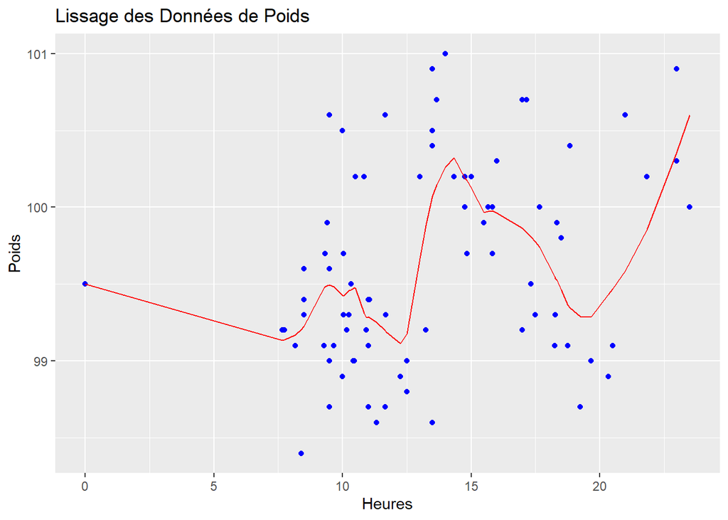

```r
# Application d'un lissage LOESS
loess_fit <- loess(Poids ~ Heures, data = data1, span = 0.3)

# Ajout des prédictions lissées
data1$Poids_Lisse <- predict(loess_fit, newdata = data1$Heures)

# Calcul des résidus ( c'est la variation pour chaque periode)
data1 <- data1 %>%
  mutate(Residus = Poids - Poids_Lisse)

# Moyenne des résidus qui est d'autre terme la variation moyenne
# on prend la valeur absolu car par exemple une variation de "1" est la meme q'une variation de "-1"
moyenne_residus <- mean(abs(data1$Residus), na.rm = TRUE)

# Visualisation
ggplot(data1, aes(x = Heures)) +
  geom_point(aes(y = Poids), color = "blue") +
  geom_line(aes(y = Poids_Lisse), color = "red") +
  labs(title = "Lissage des Données de Poids", x = "Heures", y = "Poids")
```

# QUESTION 3

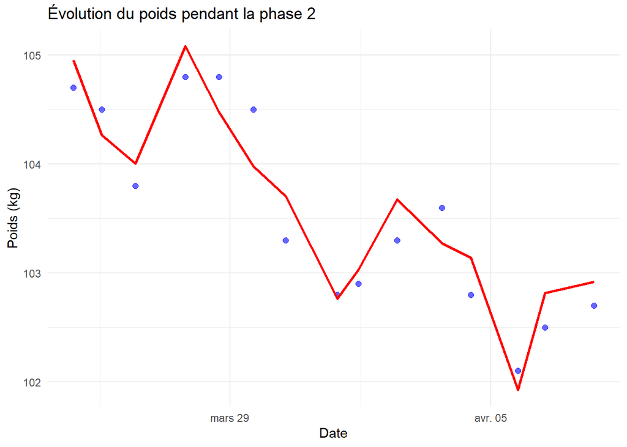

```r
# on convertie les heurs en valeur numeriques
data2$Heures <- as.numeric(difftime(data2$Date, trunc(data2$Date, "days"), units = "hours"))

# Prédictions sur les données de la seconde phase avec LOESS
data2$Poids_Lisse <- predict(loess_fit, newdata = data2$Heures)

# Calcul de l'écart moyen des valeurs lissées
moyenne_lisse <- mean(data1$Poids_Lisse)

# Ajustement des poids
data2 <- data2 %>%
  mutate(Poids_Ajuste = Poids - (Poids_Lisse - moyenne_lisse))


ggplot(data2, aes(x = Date)) +
  geom_point(aes(y = Poids), color = "blue", alpha = 0.6, size = 2) +
  geom_line(aes(y = Poids_Ajuste), color = "red", size = 1) +
  labs(title = "Évolution du poids pendant la phase 2",
       x = "Date", y = "Poids (kg)") +
  theme_minimal() +
  scale_color_manual(values = c("blue" = "Poids observé", "red" = "Poids ajusté"))
```

# QUESTION 4

```r
# ici on calcul la quantite de matiere grasse au moment ou la personne debute le regime
poids_initial <- data2$Poids_Ajuste[1]
pourcentage_initial <- data2$`Graisse_%`[1]
matiere_grasse_initiale <- poids_initial * (pourcentage_initial / 100)

# Calcul de la matière grasse pour chaque jour
data2 <- data2 %>%
  mutate(Matiere_Grasse = Poids_Ajuste * (`Graisse_%` / 100))

# Calcul de la perte de matière grasse
matiere_grasse_finale <- data2$Matiere_Grasse[nrow(data2)] # cad a la fin du regime
# ainsi il suffit juste de faire la difference entre la quantite de matire grasse au debut du regime et a la fin du regime
perte_matiere_grasse <- matiere_grasse_initiale - matiere_grasse_finale

# Affichage des résultats
print(paste("Matière grasse initiale:", matiere_grasse_initiale, "kg"))
```

```
## [1] "Matière grasse initiale: 34.4255000845287 kg"
```

```r
print(paste("Matière grasse finale:", matiere_grasse_finale, "kg"))
```

```
## [1] "Matière grasse finale: 32.00701082226 kg"
```

```r
print(paste("Perte de matière grasse:", perte_matiere_grasse, "kg"))
```

```
## [1] "Perte de matière grasse: 2.41848926226871 kg"
```

# QUESTION 5

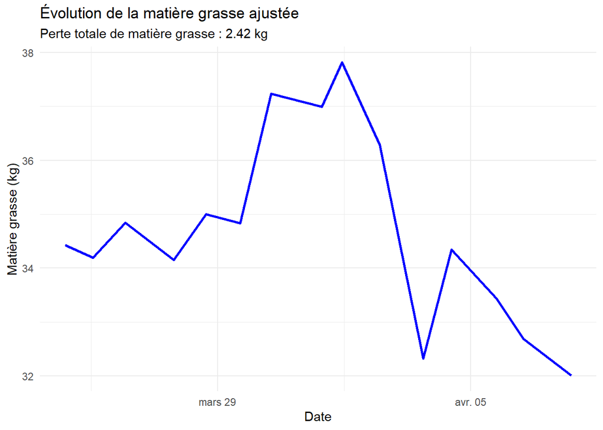

```r
# visualisation
ggplot(data2, aes(x = Date, y = Matiere_Grasse)) +
  geom_line(color = "blue", size = 1) +
  labs(title = "Évolution de la matière grasse ajustée",
       subtitle = paste("Perte totale de matière grasse :", round(perte_matiere_grasse, 2), "kg"),
       x = "Date", y = "Matière grasse (kg)") +
  theme_minimal()
```

# QUESTION 6

```r
#  Étape 1 : Ajouter la colonne `Jour_Num`

# Ajouter une colonne qui numérote les jours (1 pour le premier jour, etc.)
data2 <- data2 %>%
  mutate(Jour_Num = 1:n())

# Étape 2 : Construire le modèle de régression linéaire

# Modèle linéaire entre Jour_Num et Matiere_Grasse
modele_lineaire <- lm(Matiere_Grasse ~ Jour_Num, data = data2)

# Étape 3 : Ajouter 3 jours supplémentaires

# Créer un dataframe pour les 3 jours supplémentaires
jours_supplementaires <- data.frame(Jour_Num = max(data2$Jour_Num) + 1:3)

# Prédire la matière grasse pour les 3 jours supplémentaires
jours_supplementaires$Matiere_Grasse <- predict(modele_lineaire, newdata = jours_supplementaires)

# Étape 4 : Fusionner les données

# Fusionner les données existantes avec les jours supplémentaires
data_totale <- bind_rows(
  data2 %>% select(Jour_Num, Matiere_Grasse),
  jours_supplementaires
)

# Étape 5 : Calculer la perte totale de matière grasse

matiere_grasse_finale_extrapolee <- tail(data_totale$Matiere_Grasse, 1)
perte_matiere_grasse_totale <- data_totale$Matiere_Grasse[1] - matiere_grasse_finale_extrapolee

# Résultats

print(paste("Matière grasse extrapolée après 3 jours supplémentaires:", round(matiere_grasse_finale_extrapolee, 2), "kg"))
```

```
## [1] "Matière grasse extrapolée après 3 jours supplémentaires: 33.39 kg"
```

```r
print(paste("Perte totale de matière grasse après extrapolation:", round(perte_matiere_grasse_totale, 2), "kg"))
```

```
## [1] "Perte totale de matière grasse après extrapolation: 1.03 kg"
```

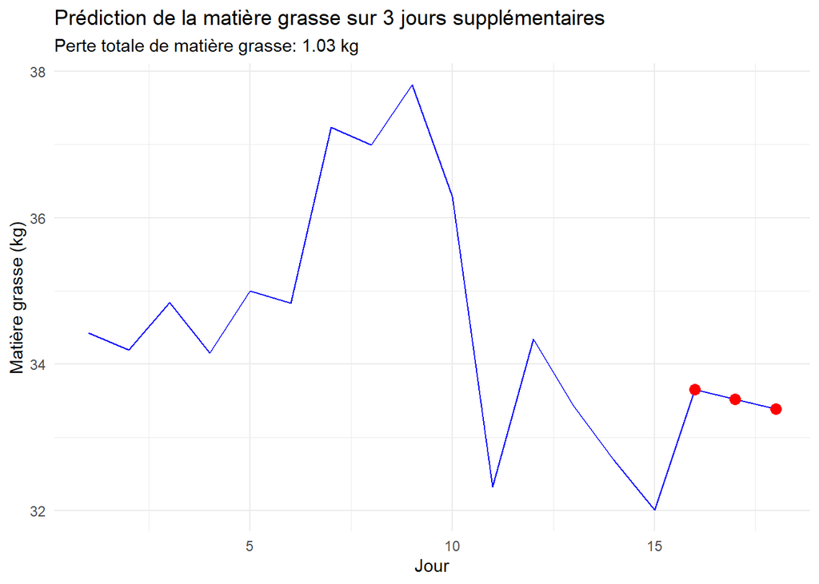

```r
# ---- Étape 6 : Visualisation ----

ggplot(data_totale, aes(x = Jour_Num, y = Matiere_Grasse)) +
  geom_line(color = "blue") +
  geom_point(data = jours_supplementaires, aes(x = Jour_Num, y = Matiere_Grasse), color = "red", size = 3) +
  labs(
    title = "Prédiction de la matière grasse sur 3 jours supplémentaires",
    subtitle = paste("Perte totale de matière grasse:", round(perte_matiere_grasse_totale, 2), "kg"),
    x = "Jour",
    y = "Matière grasse (kg)"
  ) +
  theme_minimal()
```